# Dicty analysis

# summary

Summary statistics Dicty

```
## # A tibble: 1 x 1
##   Unique_bait
##         <int>
## 1          14
```

```
## # A tibble: 1 x 1
##   Unique_bait_condition
##                   <int>
## 1                    16
```

Show how many instances (lines) of bait there are

```
##
##   Galpha1   Galpha2   Galpha4   Galpha8    Gbeta1    Gbeta2      Rac1      RapA
##      2302      4604      2302      2302      2302      2302      2302      4604
##      RasB      RasC      RasG RasG-S17N      Ric8     Roco4
##      2302      2302      2302      2302      2302      2302
```

Show how many instances (lines) of condition there are

```
##
## background    control     normal      starv
##       2302       2302      29926       2302
```

Show total spectral count per bait + condition

```
## # A tibble: 16 x 3
##    bait      condition  spectral_count
##    <fct>     <fct>               <dbl>
##  1 Galpha1   normal               5294
##  2 Galpha2   normal               5223
##  3 Galpha2   starv                1331
##  4 Galpha4   normal               5570
##  5 Galpha8   normal               7158
##  6 Gbeta1    normal               4527
##  7 Gbeta2    normal               5983
##  8 Rac1      normal               7755
##  9 RapA      control               394
## 10 RapA      normal               1617
## 11 RasB      normal               4915
## 12 RasC      normal               4283
## 13 RasG      normal               1110
## 14 RasG-S17N normal               3179
## 15 Ric8      normal               5826
## 16 Roco4     background           7025
```

Show normalized spectral count per bait + condition

```
## # A tibble: 16 x 3
##    bait      condition  z_score_spectral
##    <fct>     <fct>                 <dbl>
##  1 Galpha1   normal                192.
##  2 Galpha2   normal                176.
##  3 Galpha2   starv                -708.
##  4 Galpha4   normal                254.
##  5 Galpha8   normal                615.
##  6 Gbeta1    normal                 17.6
##  7 Gbeta2    normal                348.
##  8 Rac1      normal                750.
##  9 RapA      control              -921.
## 10 RapA      normal               -643.
## 11 RasB      normal                106.
## 12 RasC      normal                -37.8
## 13 RasG      normal               -758.
## 14 RasG-S17N normal               -288.
## 15 Ric8      normal                313.
## 16 Roco4     background            585.
```

Show how many uniq uniprot id’s are in the set (dicty has 6 chromosomes and 12500 proteins)

```
## [1] 2302
```

uniq proteins per bait_condition

```
## # A tibble: 16 x 3
## # Groups:   bait [14]
##    bait      condition  `n_distinct(uniprot)`
##    <fct>     <fct>                      <int>
##  1 Galpha1   normal                      2302
##  2 Galpha2   normal                      2302
##  3 Galpha2   starv                       2302
##  4 Galpha4   normal                      2302
##  5 Galpha8   normal                      2302
##  6 Gbeta1    normal                      2302
##  7 Gbeta2    normal                      2302
##  8 Rac1      normal                      2302
##  9 RapA      control                     2302
## 10 RapA      normal                      2302
## 11 RasB      normal                      2302
## 12 RasC      normal                      2302
## 13 RasG      normal                      2302
## 14 RasG-S17N normal                      2302
## 15 Ric8      normal                      2302
## 16 Roco4     background                  2302
```

Unique proteins per condition

```
## # A tibble: 4 x 2
##   condition  `n_distinct(uniprot)`
##   <fct>                      <int>
## 1 background                  2302
## 2 control                     2302
## 3 normal                      2302
## 4 starv                       2302
```

Unique proteins per bait

```
## # A tibble: 14 x 2
##    bait      `n_distinct(uniprot)`
##    <fct>                     <int>
##  1 Galpha1                    2302
##  2 Galpha2                    2302
##  3 Galpha4                    2302
##  4 Galpha8                    2302
##  5 Gbeta1                     2302
##  6 Gbeta2                     2302
##  7 Rac1                       2302
##  8 RapA                       2302
##  9 RasB                       2302
## 10 RasC                       2302
## 11 RasG                       2302
## 12 RasG-S17N                  2302
## 13 Ric8                       2302
## 14 Roco4                      2302
```

## absolute spectral count

Barplot showing the total spectral count for each bait

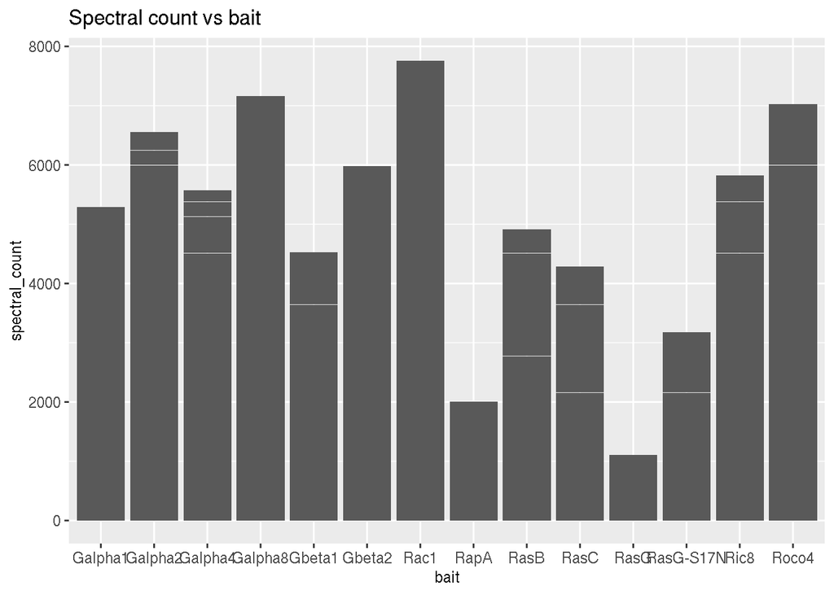

Barplot showing the absolute spectral count for each condition

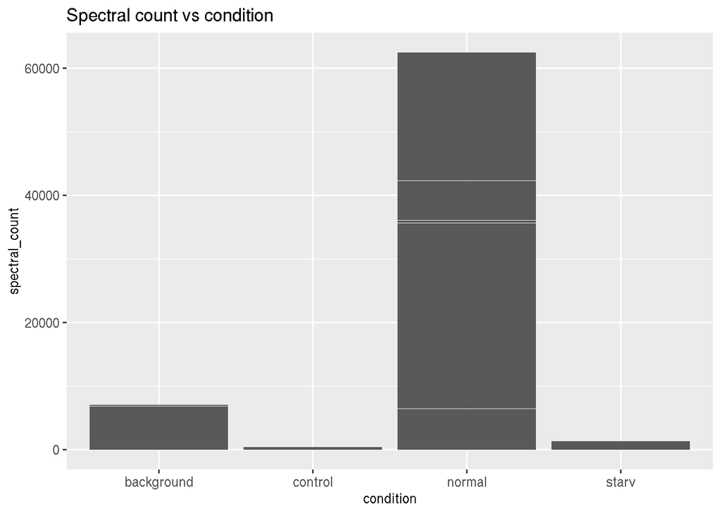

Combined spectral count for bait + condition, sum spectral count per group

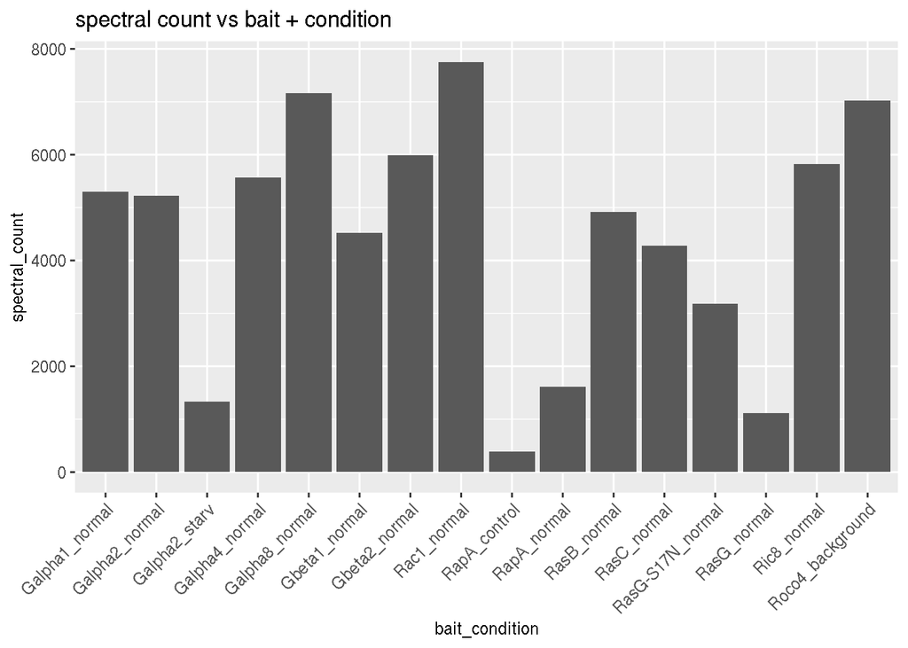

## average spectra

Barplot showing the average spectral count per protein for each bait divided the summed group count by the number of observations in that group so avg count per group

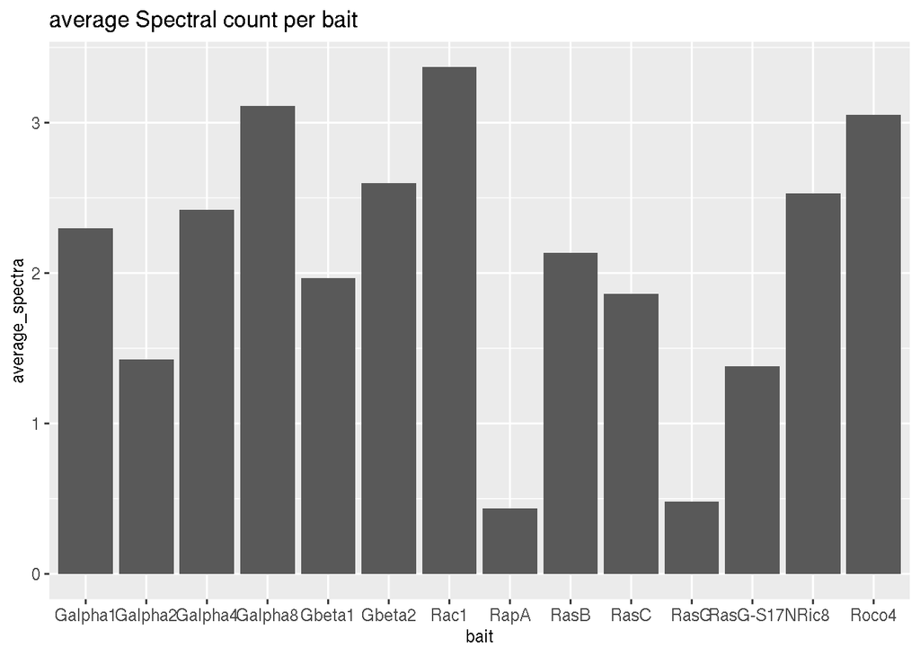

Barplot showing the average spectral count for each condition: divided the summed group count by the number of observations in that group,

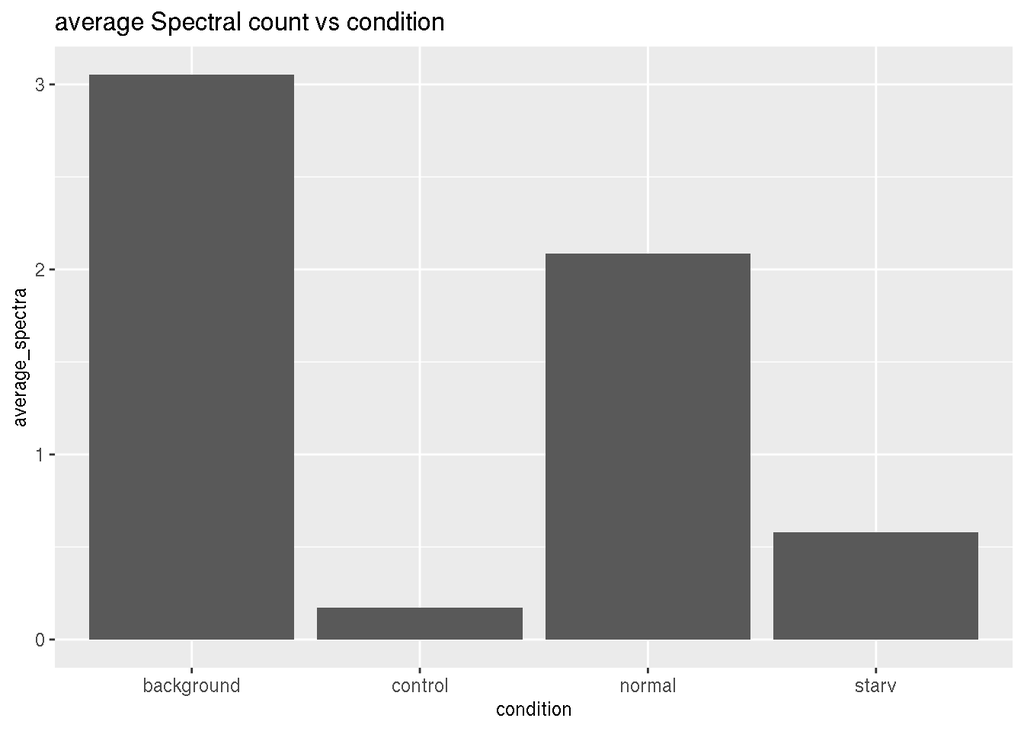

Combined spectral count for bait + condition, average spectral count per group

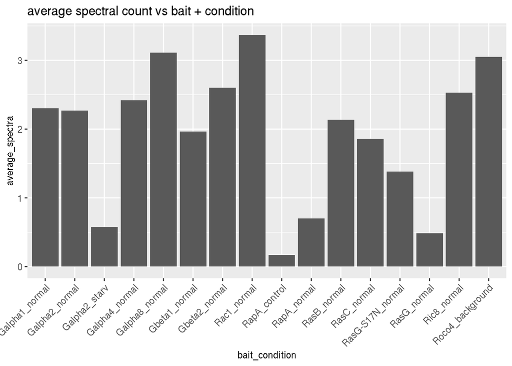

Combined spectral count for bait + condition, average spectral count per group Add overlay with unique proteins

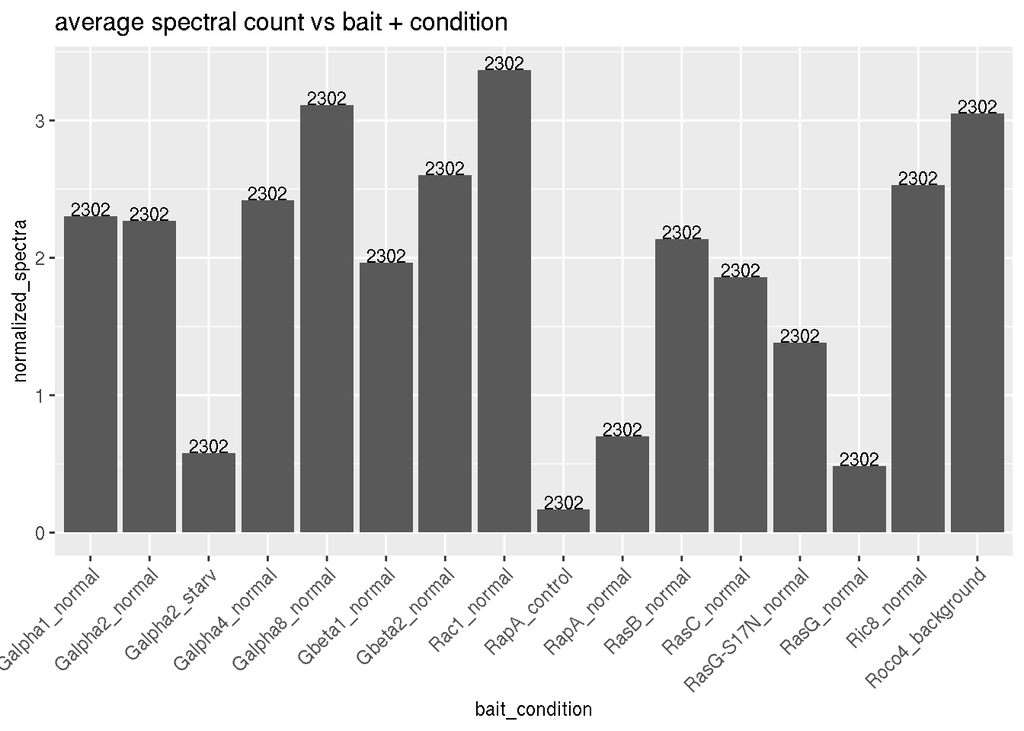

## boxplot bait absolute count

Boxplot absolute count vs bait

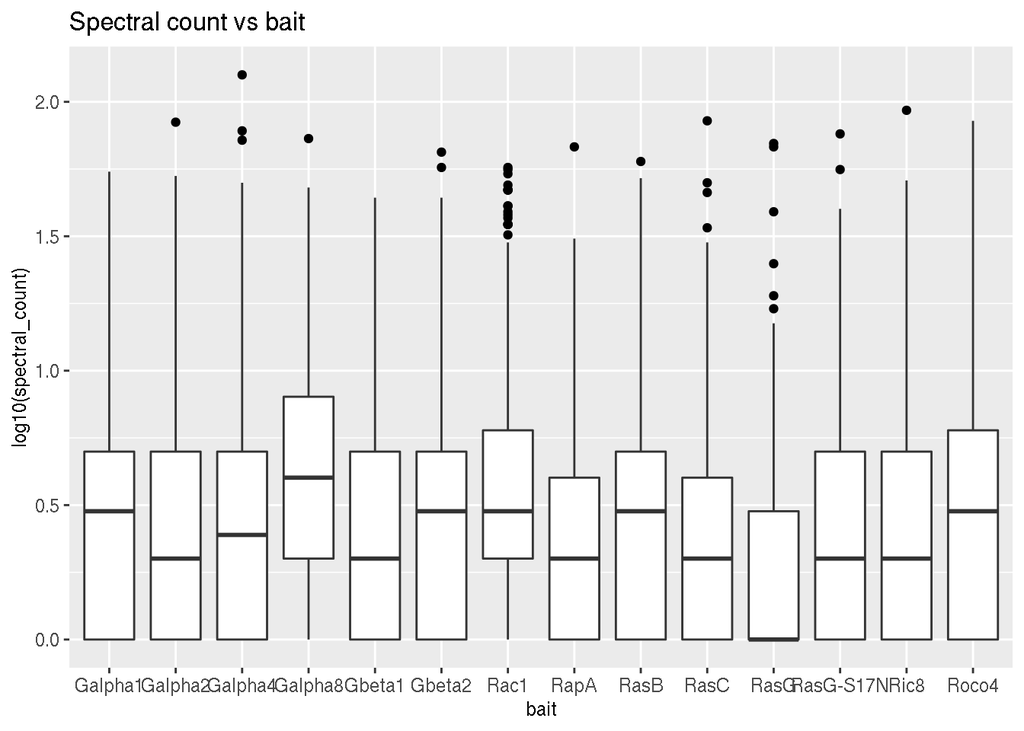

## boxplot condition absolute count

Boxplot count vs condition

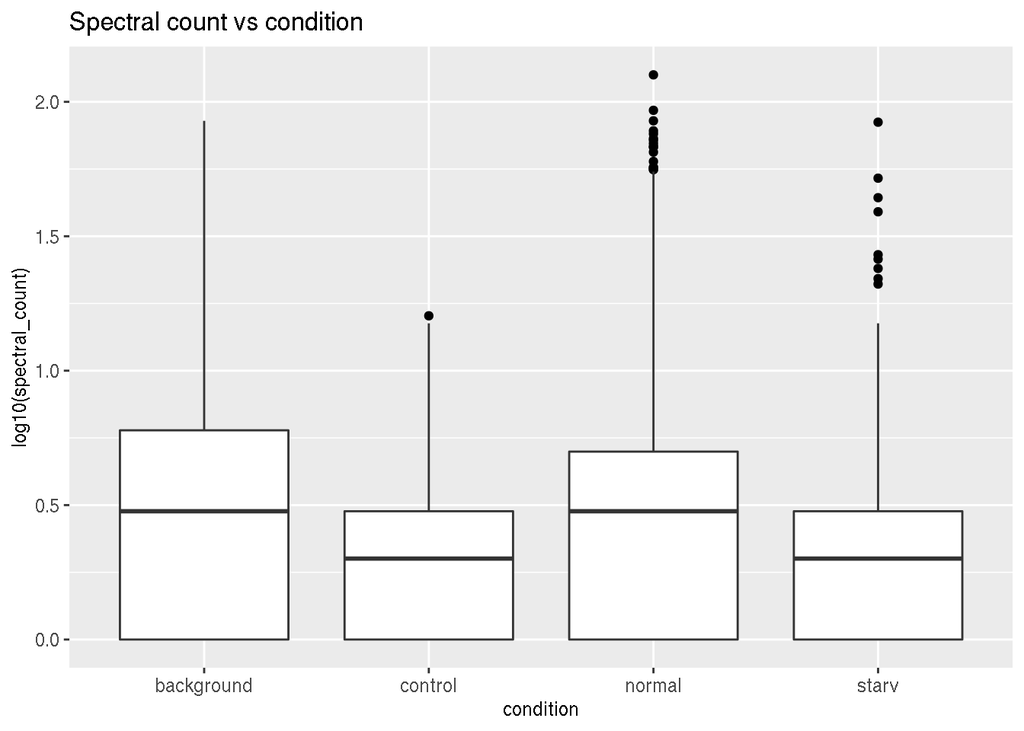

## boxplot experiment absolute count

Boxplot combined spectral count for bait + condition

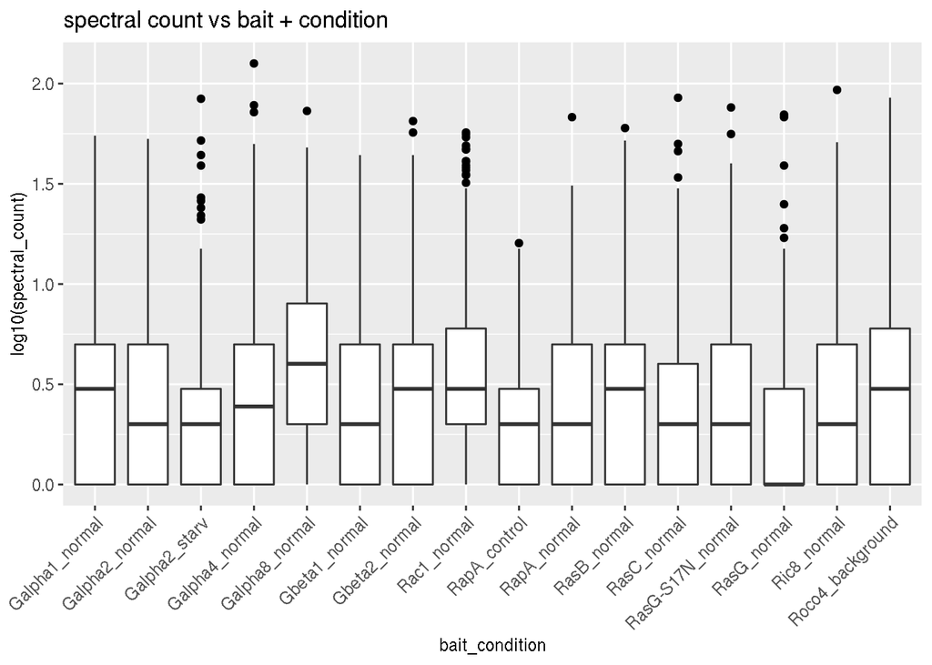

## z-score normalized boxplot count vs bait

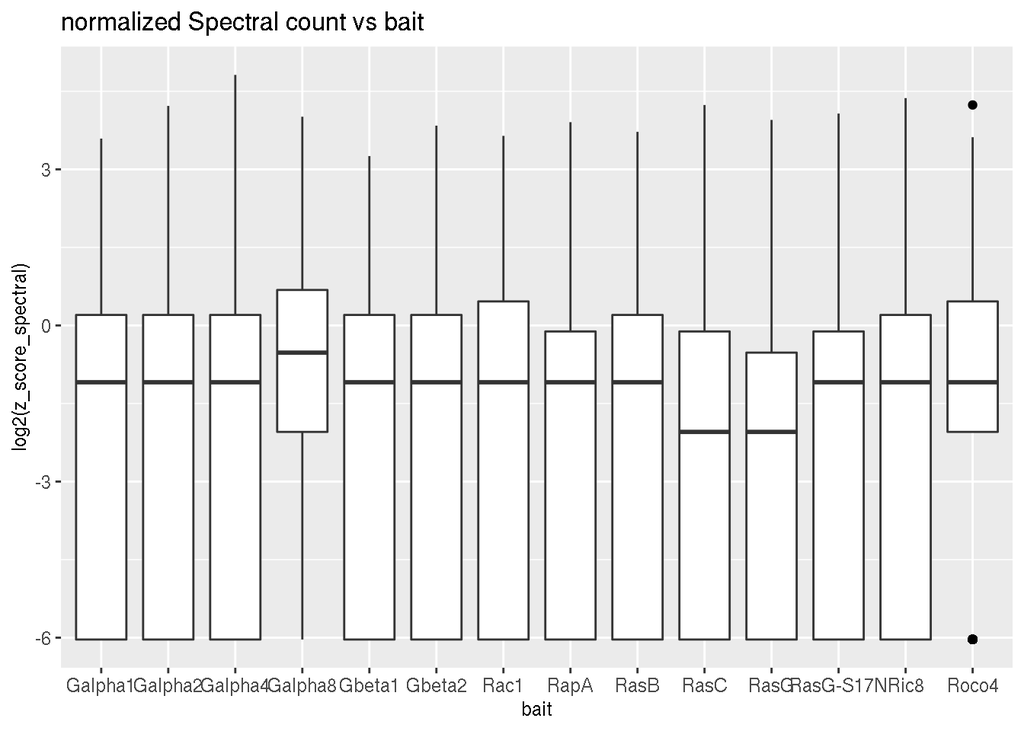

## z-score normalized boxplot count vs condition

boxplot count vs condition

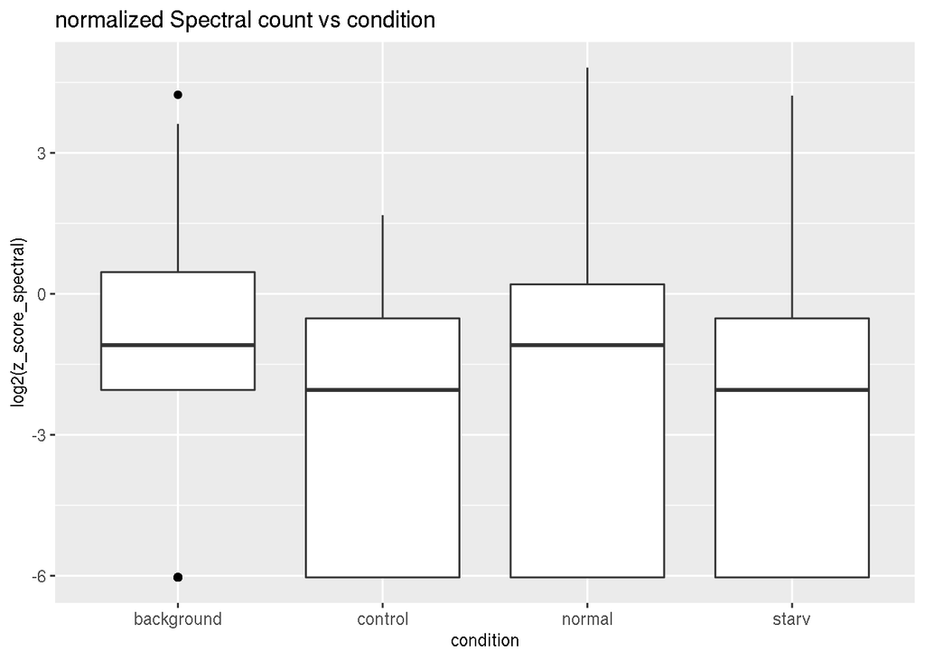

## z-score normalized boxplot boxplot count vs experiment

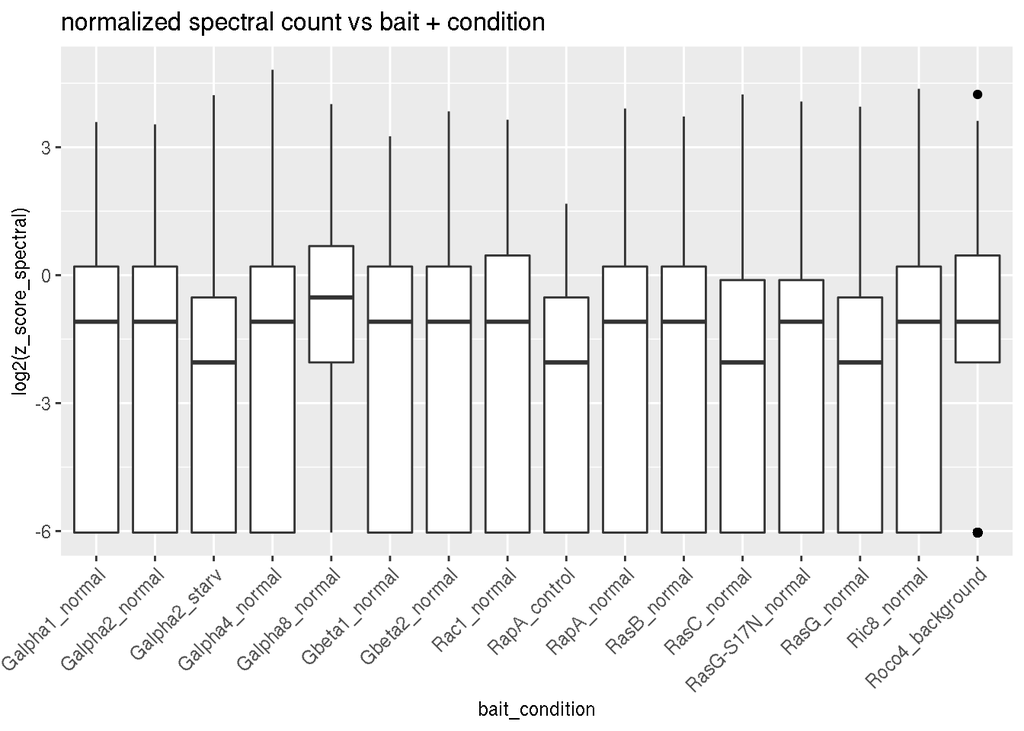

# Venn diagrams

## Venn diagrams over bait

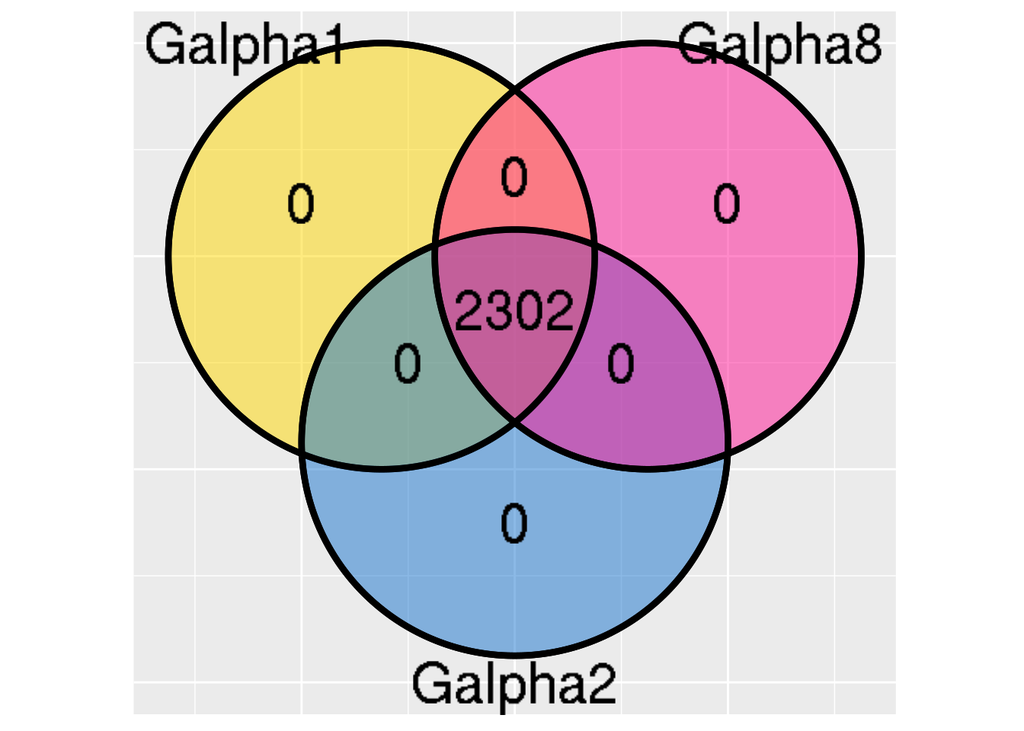

## Venn diagrams over condition

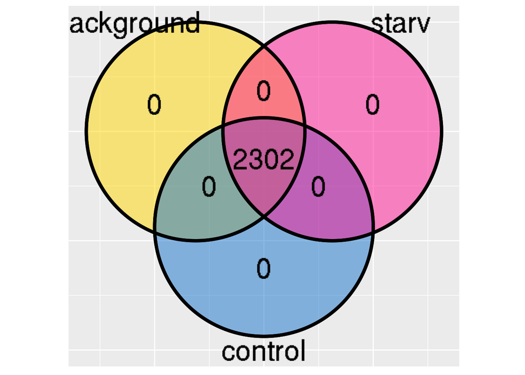

## overlap proteins per bait_condition

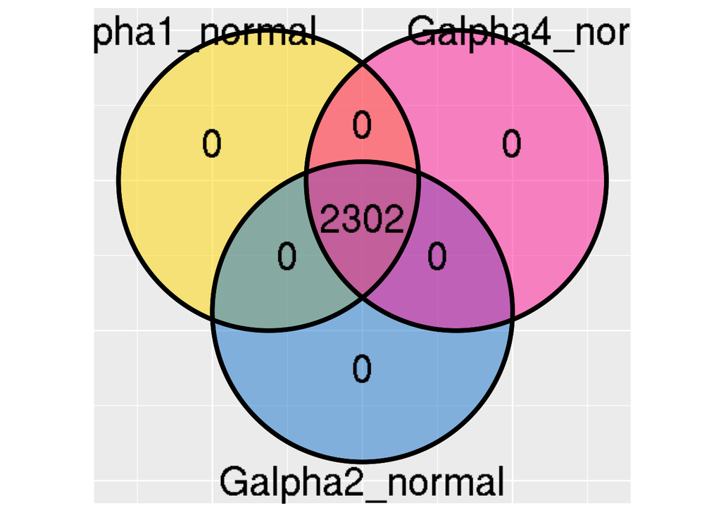

Method to retrieve the overlapping proteins per experiment

# Presence/absence protein

Heatmap for uniprot presence/absence over bait, condition or experiment. Filtered on protein

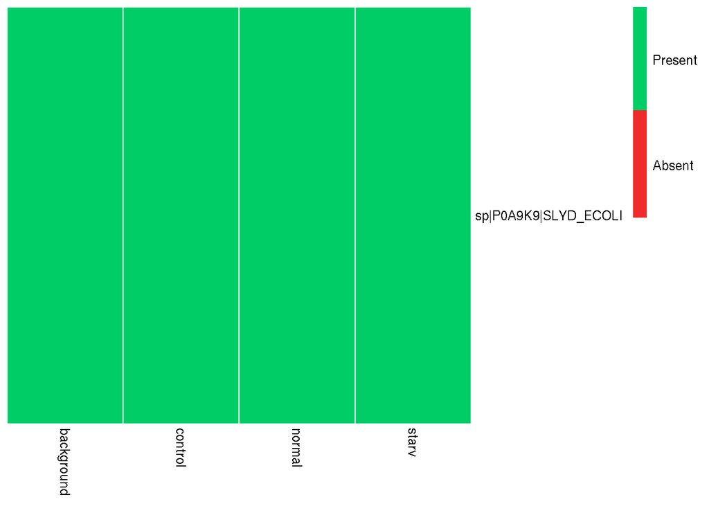

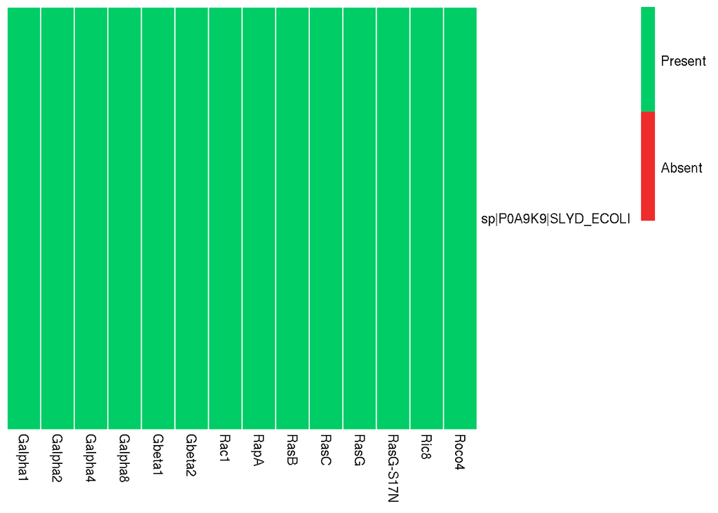

# Overlapping proteins

```
##                  Galpha1_normal Galpha2_normal Galpha2_starv Galpha4_normal
## Galpha1_normal             2302           2302          2302           2302
## Galpha2_normal             2302           2302          2302           2302
## Galpha2_starv              2302           2302          2302           2302
## Galpha4_normal             2302           2302          2302           2302
## Galpha8_normal             2302           2302          2302           2302
## Gbeta1_normal              2302           2302          2302           2302
## Gbeta2_normal              2302           2302          2302           2302
## Rac1_normal                2302           2302          2302           2302
## RapA_control               2302           2302          2302           2302
## RapA_normal                2302           2302          2302           2302
## RasB_normal                2302           2302          2302           2302
## RasC_normal                2302           2302          2302           2302
## RasG-S17N_normal           2302           2302          2302           2302
## RasG_normal                2302           2302          2302           2302
## Ric8_normal                2302           2302          2302           2302
## Roco4_background           2302           2302          2302           2302
##                  Galpha8_normal Gbeta1_normal Gbeta2_normal Rac1_normal
## Galpha1_normal             2302          2302          2302        2302
## Galpha2_normal             2302          2302          2302        2302
## Galpha2_starv              2302          2302          2302        2302
## Galpha4_normal             2302          2302          2302        2302
## Galpha8_normal             2302          2302          2302        2302
## Gbeta1_normal              2302          2302          2302        2302
## Gbeta2_normal              2302          2302          2302        2302
## Rac1_normal                2302          2302          2302        2302
## RapA_control               2302          2302          2302        2302
## RapA_normal                2302          2302          2302        2302
## RasB_normal                2302          2302          2302        2302
## RasC_normal                2302          2302          2302        2302
## RasG-S17N_normal           2302          2302          2302        2302
## RasG_normal                2302          2302          2302        2302
## Ric8_normal                2302          2302          2302        2302
## Roco4_background           2302          2302          2302        2302
##                  RapA_control RapA_normal RasB_normal RasC_normal
## Galpha1_normal           2302        2302        2302        2302
## Galpha2_normal           2302        2302        2302        2302
## Galpha2_starv            2302        2302        2302        2302
## Galpha4_normal           2302        2302        2302        2302
## Galpha8_normal           2302        2302        2302        2302
```

[output cut: 13 more lines]

```
## Galpha2_normal               2302        2302        2302             2302
## Galpha2_starv                2302        2302        2302             2302
## Galpha4_normal               2302        2302        2302             2302
## Galpha8_normal               2302        2302        2302             2302
## Gbeta1_normal                2302        2302        2302             2302
## Gbeta2_normal                2302        2302        2302             2302
## Rac1_normal                  2302        2302        2302             2302
## RapA_control                 2302        2302        2302             2302
## RapA_normal                  2302        2302        2302             2302
## RasB_normal                  2302        2302        2302             2302
## RasC_normal                  2302        2302        2302             2302
## RasG-S17N_normal             2302        2302        2302             2302
## RasG_normal                  2302        2302        2302             2302
## Ric8_normal                  2302        2302        2302             2302
## Roco4_background             2302        2302        2302             2302
```

```
## [1] 0
```

## Simple heatmap with clustering on overlapping proteins per experiment

[figure not shown]

## ggplot heatmap overlapping proteins per experiment

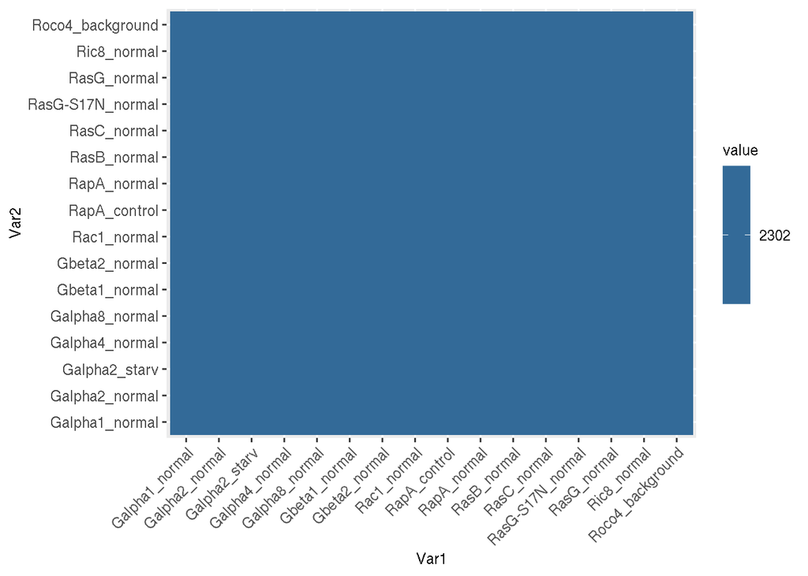

# Correlations

## raw data

### bait heatmap on raw spectra correlation

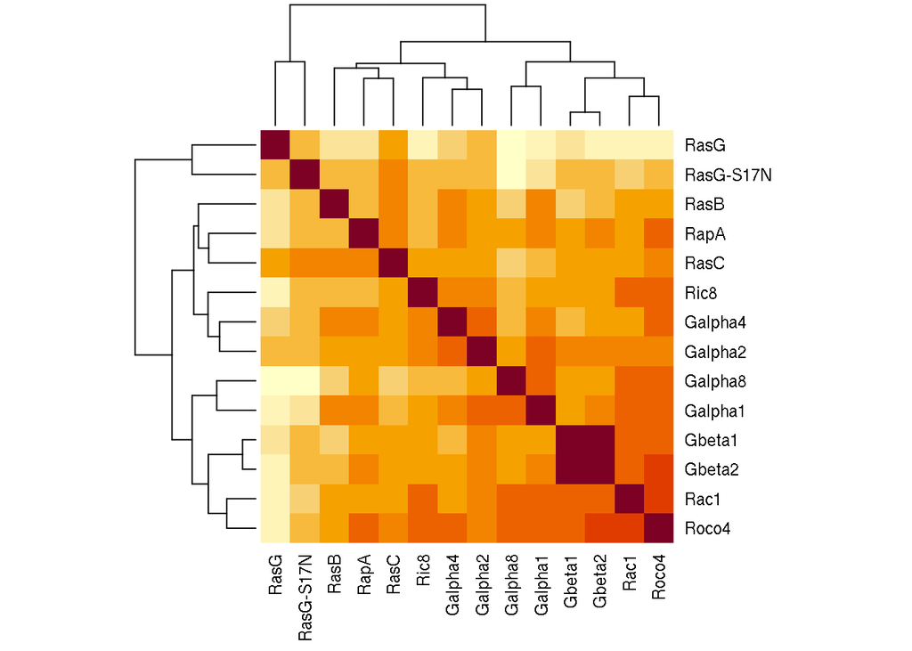

### Condition heatmap on raw spectra correlation

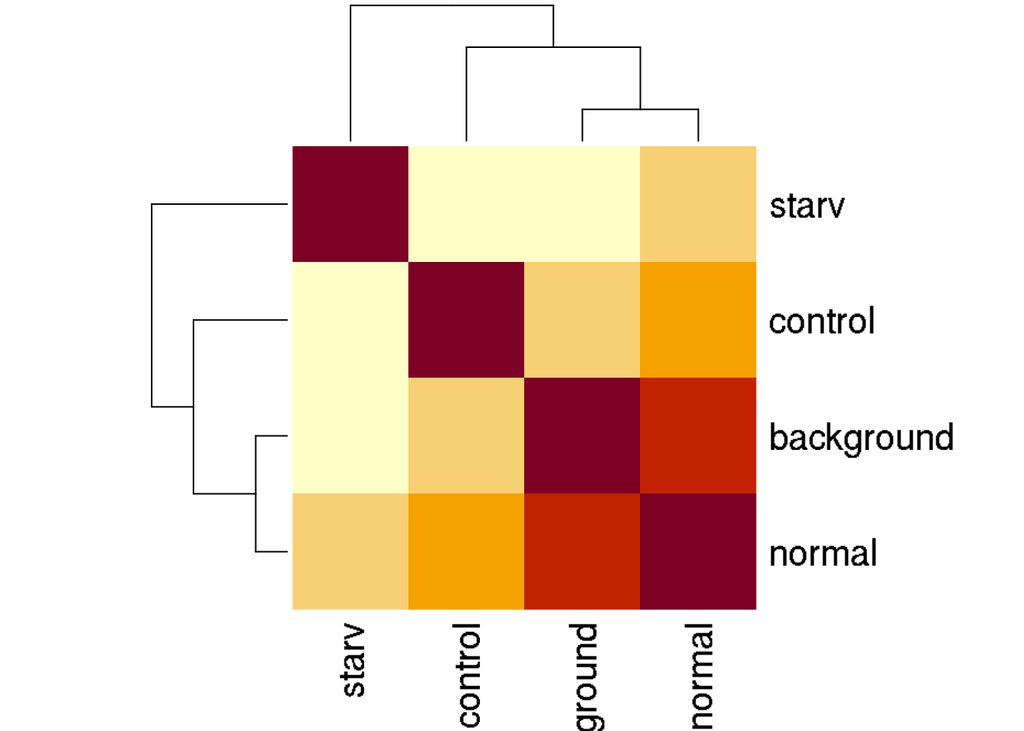

### Experiment heatmap on raw spectra correlation

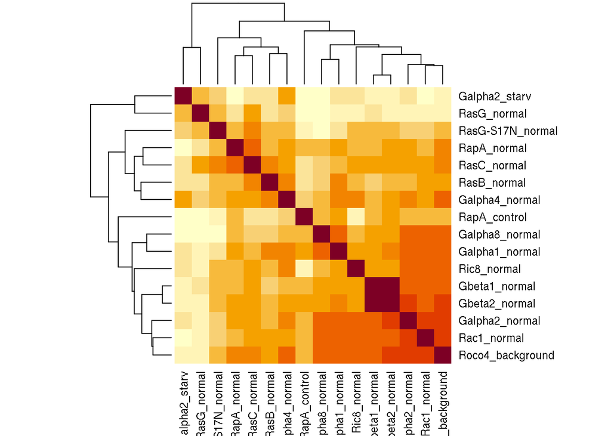

## Normalized data

### Bait heatmap on normalized spectra correlation

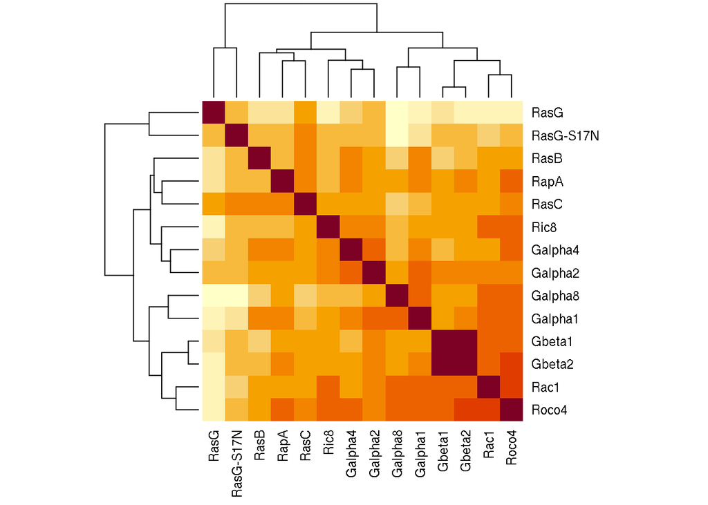

### Condition heatmap on normalized spectra correlation

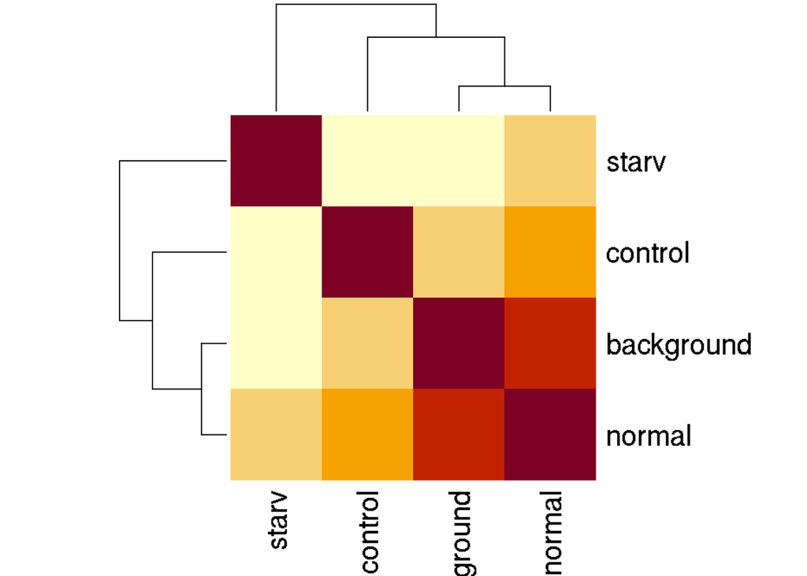

### Experiment heatmap on normalized spectra correlation

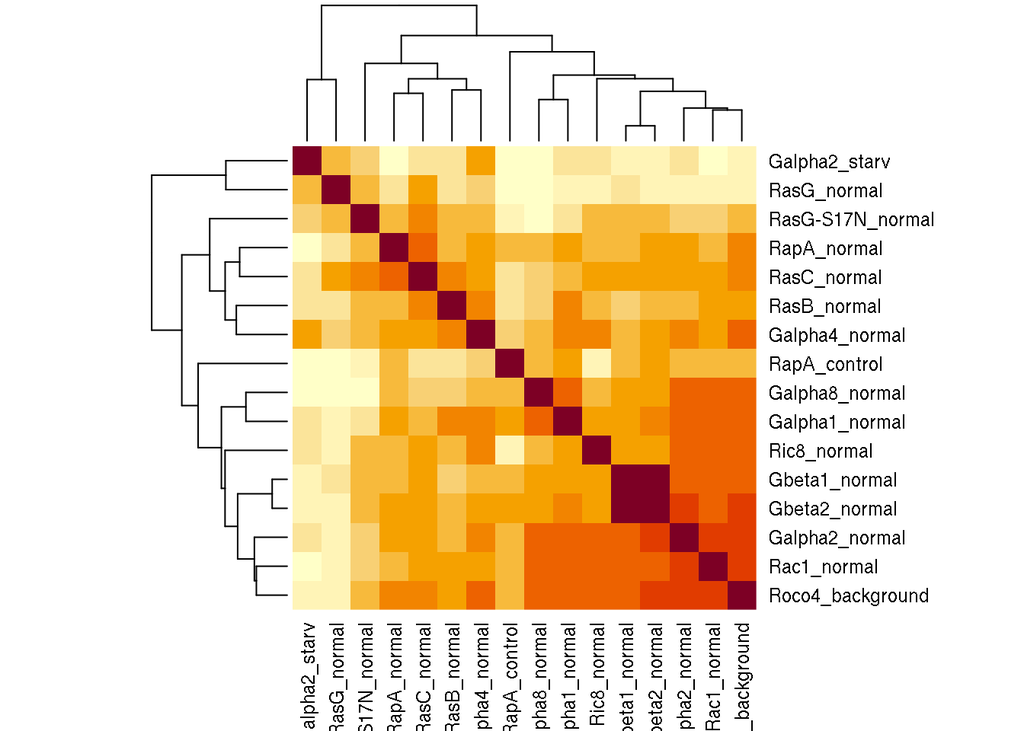

# PCA

## bait on raw spectral_count

```
## Importance of components:
##                            PC1     PC2     PC3     PC4      PC5      PC6
## Standard deviation     83.8932 56.9473 51.2653 45.1304 42.03227 38.25040
## Proportion of Variance  0.2954  0.1361  0.1103  0.0855  0.07416  0.06142
## Cumulative Proportion   0.2954  0.4316  0.5419  0.6274  0.70154  0.76296
##                             PC7     PC8      PC9     PC10     PC11     PC12
## Standard deviation     34.59186 32.4875 31.58673 28.71592 27.64644 25.17737
## Proportion of Variance  0.05023  0.0443  0.04188  0.03461  0.03208  0.02661
## Cumulative Proportion   0.81319  0.8575  0.89937  0.93398  0.96607  0.99268
##                            PC13      PC14
## Standard deviation     13.20847 1.166e-13
## Proportion of Variance  0.00732 0.000e+00
## Cumulative Proportion   1.00000 1.000e+00
```

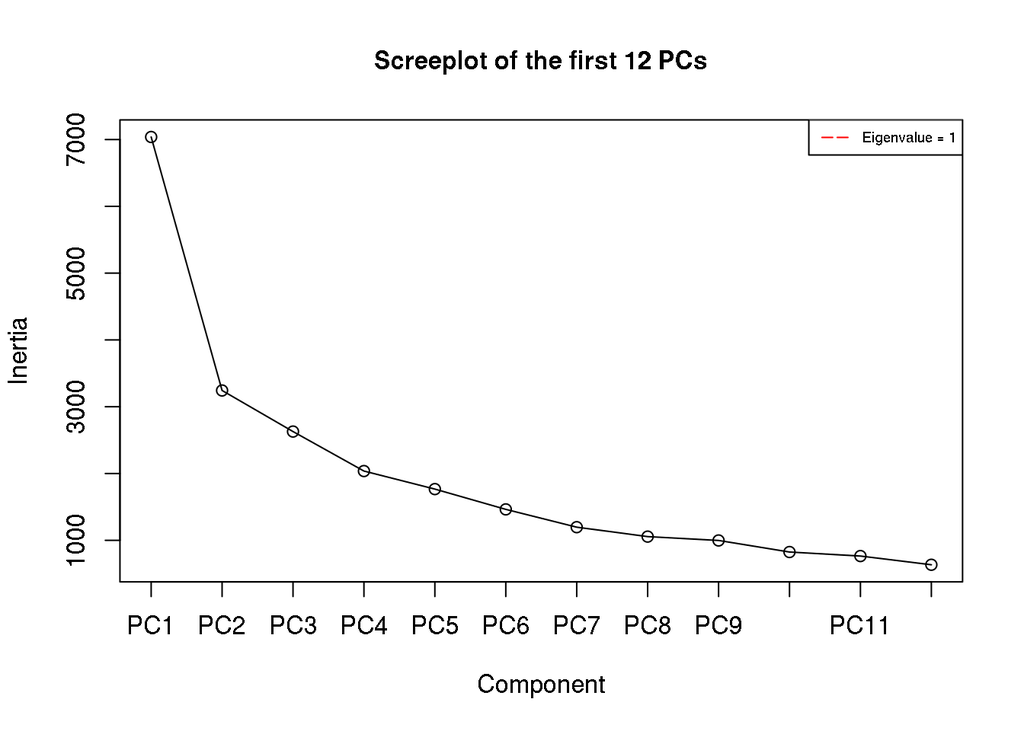

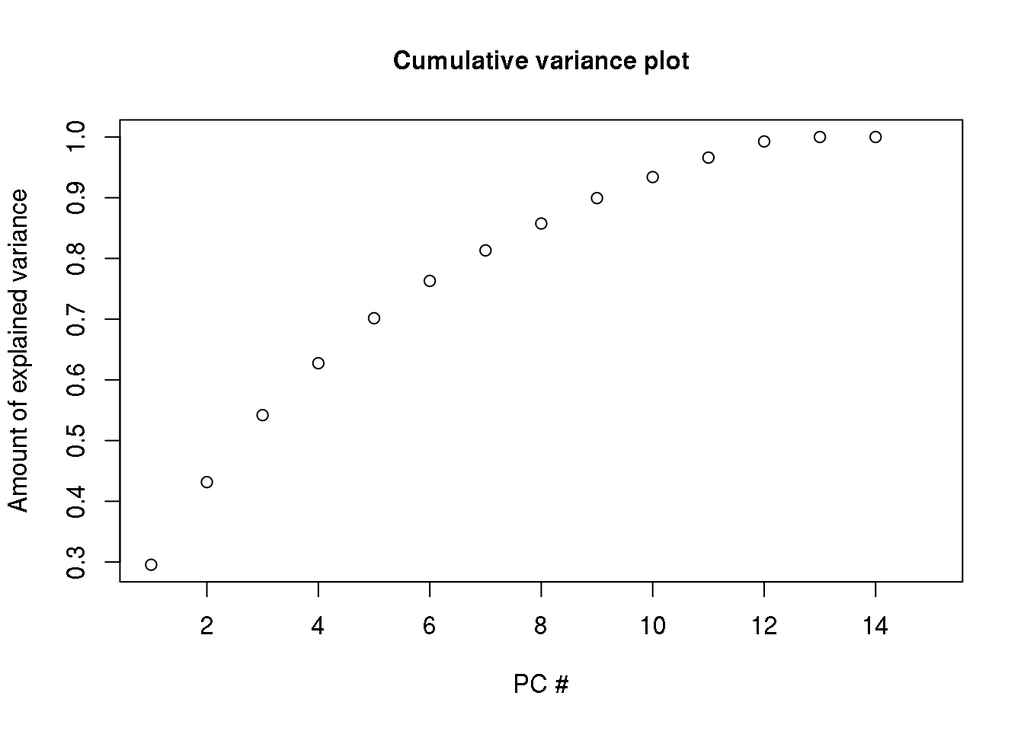

[figure not shown]

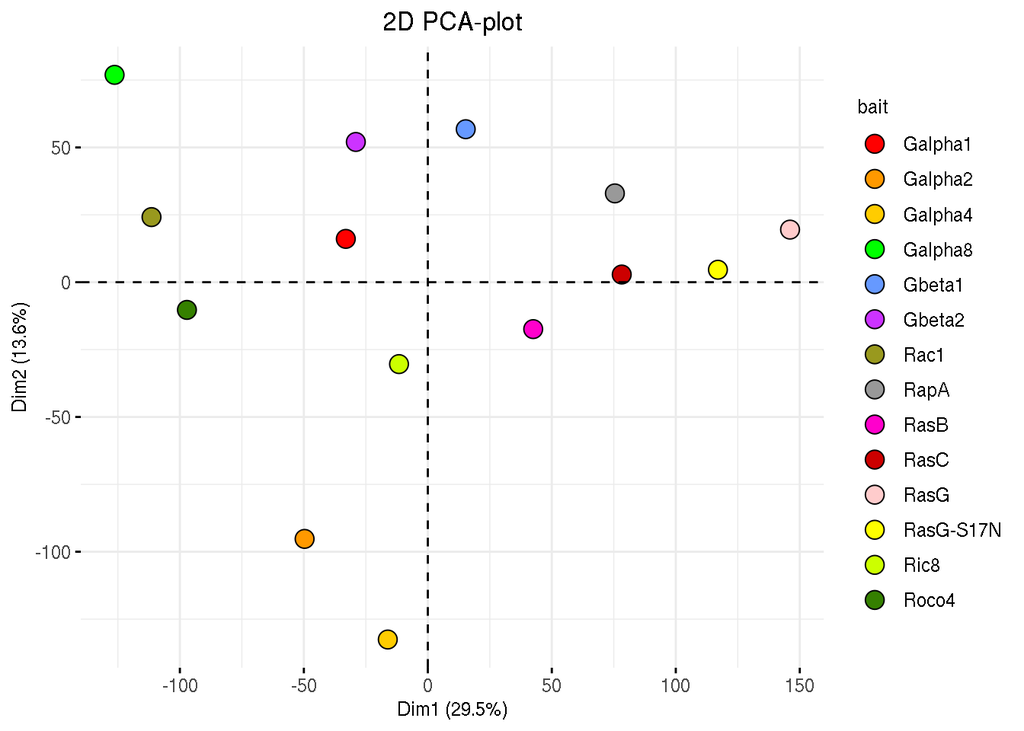